# RNA-Seq

Sadiq Alhasan

12/15/2019

## Introduction

The data set used in this workflow is from an RNA-Seq experiment. There are 16 samples where all are of cell line HUDEP2 (Human Umbilical Cord Blood-Derived Erythroid Progenitor). 8 samples have wild-type genotype and 8 with knockout gene “ZBTB7A”. ZBTB7A gene produces LRF transcription factor that represses the expression of fetal β-like globin in adult red blood cells.

## Downloading the Data Set

The data set used in this workflow was downloaded from the recount2 (“https://jhubiostatistics.shinyapps.io/recount/”) as a ranged summarized experiment. The accession code to this data set is “SRP066151”.

```r
## Download the data if it is not there
if(!file.exists(file.path("SRP066151", "rse_gene.Rdata"))) {
  download_study("SRP066151", type = "rse-gene")
}

# load the dataset
load(file.path("SRP066151", "rse_gene.Rdata"))
```

## Preprocessing

Two new columns were are added to the data set `rse_gene` colData. The first column is cell_type, which indicates the genotype of the samples (WT vs KO). The second column is cell_stage, which indicates the stage at which the cells “samples” were when RNA-Seq was performed (Early basophilic erythroblasts “EBE” vs Late basophilic erythroblasts “LBE”).

```r
# create a new vector containing the cell type
cell_type <- ifelse(grepl('WT', colData(rse_gene)$title), 'WT', 'KO')
```

```r
# add cell_type as a factor to colData rse_gene
colData(rse_gene)$cell_type <- as.factor(cell_type)
```

```r
# re-level to set reference as the wild type
relevel(rse_gene$cell_type, "WT")
```

```
##  [1] KO KO KO KO WT WT WT WT KO KO KO KO WT WT WT WT
## Levels: WT KO
```

```r
# select the first 2 characteristics to for each sample
char <- sapply(colData(rse_gene)$characteristics, "[", 1:2)
```

```r
# extract the information desired
char_split <- sapply(strsplit(char, ": "), "[", 2)
```

```r
# combine the 2 characteristics to for each sample in one line
# save results as new_cell_stage
new_cell_stage <- matrix(ncol = 1, nrow = 16)
for ( i in 1:length(colnames(rse_gene)) ){
  position <- seq(1,31,2)
  new_cell_stage[i] <- rbind(paste0(char_split[position[i]]," ",char_split[(position+1)[i]]))
  if (i < length(char_split)) {
    i <- 1 + i
  }

}
```

```r
#check if new_cell_stage has the correct output vlaues
new_cell_stage
```

```
##       [,1]
##  [1,] "Late basophilic erythroblasts EDM-II doxycycline+ (Day5)"
##  [2,] "Late basophilic erythroblasts EDM-II doxycycline+ (Day5)"
##  [3,] "Early basophilic erythroblasts SFEM doxycycline+ (Day0)"
##  [4,] "Early basophilic erythroblasts SFEM doxycycline+ (Day0)"
##  [5,] "Late basophilic erythroblasts EDM-II doxycycline+ (Day5)"
##  [6,] "Late basophilic erythroblasts EDM-II doxycycline+ (Day5)"
##  [7,] "Early basophilic erythroblasts SFEM doxycycline+ (Day0)"
##  [8,] "Early basophilic erythroblasts SFEM doxycycline+ (Day0)"
##  [9,] "Late basophilic erythroblasts EDM-II doxycycline+ (Day5)"
## [10,] "Late basophilic erythroblasts EDM-II doxycycline+ (Day5)"
## [11,] "Early basophilic erythroblasts SFEM doxycycline+ (Day0)"
## [12,] "Early basophilic erythroblasts SFEM doxycycline+ (Day0)"
## [13,] "Late basophilic erythroblasts EDM-II doxycycline+ (Day5)"
## [14,] "Late basophilic erythroblasts EDM-II doxycycline+ (Day5)"
## [15,] "Early basophilic erythroblasts SFEM doxycycline+ (Day0)"
## [16,] "Early basophilic erythroblasts SFEM doxycycline+ (Day0)"
```

```r
# convert new_cell_stage to factors as cell_stage
cell_stage <- factor(new_cell_stage)
```

```r
# check cell_stage values
cell_stage
```

```
##  [1] Late basophilic erythroblasts EDM-II doxycycline+ (Day5)
##  [2] Late basophilic erythroblasts EDM-II doxycycline+ (Day5)
##  [3] Early basophilic erythroblasts SFEM doxycycline+ (Day0)
##  [4] Early basophilic erythroblasts SFEM doxycycline+ (Day0)
##  [5] Late basophilic erythroblasts EDM-II doxycycline+ (Day5)
##  [6] Late basophilic erythroblasts EDM-II doxycycline+ (Day5)
##  [7] Early basophilic erythroblasts SFEM doxycycline+ (Day0)
##  [8] Early basophilic erythroblasts SFEM doxycycline+ (Day0)
##  [9] Late basophilic erythroblasts EDM-II doxycycline+ (Day5)
## [10] Late basophilic erythroblasts EDM-II doxycycline+ (Day5)
## [11] Early basophilic erythroblasts SFEM doxycycline+ (Day0)
## [12] Early basophilic erythroblasts SFEM doxycycline+ (Day0)
## [13] Late basophilic erythroblasts EDM-II doxycycline+ (Day5)
## [14] Late basophilic erythroblasts EDM-II doxycycline+ (Day5)
## [15] Early basophilic erythroblasts SFEM doxycycline+ (Day0)
## [16] Early basophilic erythroblasts SFEM doxycycline+ (Day0)
## 2 Levels: Early basophilic erythroblasts SFEM doxycycline+ (Day0) ...
```

```r
#rename the factors

levels(cell_stage)[levels(cell_stage)=="Late basophilic erythroblasts EDM-II doxycycline+ (Day5)"] <- "LBE"

levels(cell_stage)[levels(cell_stage)=="Early basophilic erythroblasts SFEM doxycycline+ (Day0)"] <- "EBE"

# and check levels
levels(cell_stage)
```

```
## [1] "EBE" "LBE"
```

```r
# add back to colData of rse_gene
rse_gene$cell_stage <- cell_stage
```

```r
# reset levels
relevel(rse_gene$cell_stage, "EBE")
```

```
##  [1] LBE LBE EBE EBE LBE LBE EBE EBE LBE LBE EBE EBE LBE LBE EBE EBE
## Levels: EBE LBE
```

```r
# check if the new column (cell_stage) is added
colnames(colData(rse_gene))
```

```
##  [1] "project"
##  [2] "sample"
##  [3] "experiment"
##  [4] "run"
##  [5] "read_count_as_reported_by_sra"
##  [6] "reads_downloaded"
##  [7] "proportion_of_reads_reported_by_sra_downloaded"
##  [8] "paired_end"
##  [9] "sra_misreported_paired_end"
## [10] "mapped_read_count"
## [11] "auc"
## [12] "sharq_beta_tissue"
## [13] "sharq_beta_cell_type"
## [14] "biosample_submission_date"
## [15] "biosample_publication_date"
## [16] "biosample_update_date"
## [17] "avg_read_length"
## [18] "geo_accession"
## [19] "bigwig_file"
## [20] "title"
## [21] "characteristics"
## [22] "cell_type"
## [23] "cell_stage"
```

```r
rse_gene$cell_stage
```

```
##  [1] LBE LBE EBE EBE LBE LBE EBE EBE LBE LBE EBE EBE LBE LBE EBE EBE
## Levels: EBE LBE
```

```r
# view the two cloumns side by side to check that the have the
# correct values/order (cell_stage vs characteristics)
colData(rse_gene)[, c("cell_stage", "characteristics")]
```

```
## DataFrame with 16 rows and 2 columns
##            cell_stage
##              <factor>
## SRR2923145        LBE
## SRR2923146        LBE
## SRR2923143        EBE
## SRR2923144        EBE
## SRR2923141        LBE
## ...               ...
## SRR2923136        EBE
## SRR2923133        LBE
## SRR2923134        LBE
## SRR2923131        EBE
## SRR2923132        EBE
##                                                                                                                characteristics
##                                                                                                                <CharacterList>
## SRR2923145 differentiation stage: Late basophilic erythroblasts,culture condition: EDM-II doxycycline+ (Day5),mouse strain: NA
## SRR2923146 differentiation stage: Late basophilic erythroblasts,culture condition: EDM-II doxycycline+ (Day5),mouse strain: NA
## SRR2923143  differentiation stage: Early basophilic erythroblasts,culture condition: SFEM doxycycline+ (Day0),mouse strain: NA
## SRR2923144  differentiation stage: Early basophilic erythroblasts,culture condition: SFEM doxycycline+ (Day0),mouse strain: NA
## SRR2923141 differentiation stage: Late basophilic erythroblasts,culture condition: EDM-II doxycycline+ (Day5),mouse strain: NA
## ...                                                                                                                        ...
## SRR2923136  differentiation stage: Early basophilic erythroblasts,culture condition: SFEM doxycycline+ (Day0),mouse strain: NA
## SRR2923133 differentiation stage: Late basophilic erythroblasts,culture condition: EDM-II doxycycline+ (Day5),mouse strain: NA
## SRR2923134 differentiation stage: Late basophilic erythroblasts,culture condition: EDM-II doxycycline+ (Day5),mouse strain: NA
## SRR2923131  differentiation stage: Early basophilic erythroblasts,culture condition: SFEM doxycycline+ (Day0),mouse strain: NA
## SRR2923132  differentiation stage: Early basophilic erythroblasts,culture condition: SFEM doxycycline+ (Day0),mouse strain: NA
```

## Viewing the Data

```r
# Checking the dimensions (number of rows and columns)
dim(rse_gene)
```

```
## [1] 58037    16
```

```r
# viewing the table containing the data about the samples
colData(rse_gene)
```

```
## DataFrame with 16 rows and 23 columns
##                project      sample  experiment         run
##            <character> <character> <character> <character>
## SRR2923145   SRP066151  SRS1161495  SRX1430708  SRR2923145
## SRR2923146   SRP066151  SRS1161495  SRX1430708  SRR2923146
## SRR2923143   SRP066151  SRS1161496  SRX1430707  SRR2923143
## SRR2923144   SRP066151  SRS1161496  SRX1430707  SRR2923144
## SRR2923141   SRP066151  SRS1161497  SRX1430706  SRR2923141
## ...                ...         ...         ...         ...
## SRR2923136   SRP066151  SRS1161500  SRX1430703  SRR2923136
## SRR2923133   SRP066151  SRS1161501  SRX1430702  SRR2923133
## SRR2923134   SRP066151  SRS1161501  SRX1430702  SRR2923134
## SRR2923131   SRP066151  SRS1161502  SRX1430701  SRR2923131
## SRR2923132   SRP066151  SRS1161502  SRX1430701  SRR2923132
##            read_count_as_reported_by_sra reads_downloaded
##                                <integer>        <integer>
## SRR2923145                      53991816         53991816
## SRR2923146                      53083064         53083064
## SRR2923143                      59346502         59346502
## SRR2923144                      59932408         59932408
## SRR2923141                      64798976         64798976
## ...                                  ...              ...
## SRR2923136                      58647000         58647000
## SRR2923133                      64321850         64321850
## SRR2923134                      65097422         65097422
## SRR2923131                      63740456         63740456
## SRR2923132                      64552440         64552440
##            proportion_of_reads_reported_by_sra_downloaded paired_end
##                                                 <numeric>  <logical>
## SRR2923145                                              1       TRUE
## SRR2923146                                              1       TRUE
## SRR2923143                                              1       TRUE
## SRR2923144                                              1       TRUE
## SRR2923141                                              1       TRUE
## ...                                                   ...        ...
## SRR2923136                                              1       TRUE
## SRR2923133                                              1       TRUE
## SRR2923134                                              1       TRUE
## SRR2923131                                              1       TRUE
## SRR2923132                                              1       TRUE
```

[output cut: 63 more lines]

```
## SRR2923131  differentiation stage: Early basophilic erythroblasts,culture condition: SFEM doxycycline+ (Day0),mouse strain: NA
## SRR2923132  differentiation stage: Early basophilic erythroblasts,culture condition: SFEM doxycycline+ (Day0),mouse strain: NA
##            cell_type cell_stage
##             <factor>   <factor>
## SRR2923145        KO        LBE
## SRR2923146        KO        LBE
## SRR2923143        KO        EBE
## SRR2923144        KO        EBE
## SRR2923141        WT        LBE
## ...              ...        ...
## SRR2923136        KO        EBE
## SRR2923133        WT        LBE
## SRR2923134        WT        LBE
## SRR2923131        WT        EBE
## SRR2923132        WT        EBE
```

```r
# viewing the table containing the data about the genes

rowRanges(rse_gene)
```

```
## GRanges object with 58037 ranges and 3 metadata columns:
##                      seqnames              ranges strand |            gene_id
##                         <Rle>           <IRanges>  <Rle> |        <character>
##   ENSG00000000003.14     chrX 100627109-100639991      - | ENSG00000000003.14
##    ENSG00000000005.5     chrX 100584802-100599885      + |  ENSG00000000005.5
##   ENSG00000000419.12    chr20   50934867-50958555      - | ENSG00000000419.12
##   ENSG00000000457.13     chr1 169849631-169894267      - | ENSG00000000457.13
##   ENSG00000000460.16     chr1 169662007-169854080      + | ENSG00000000460.16
##                  ...      ...                 ...    ... .                ...
##    ENSG00000283695.1    chr19   52865369-52865429      - |  ENSG00000283695.1
##    ENSG00000283696.1     chr1 161399409-161422424      + |  ENSG00000283696.1
##    ENSG00000283697.1     chrX 149548210-149549852      - |  ENSG00000283697.1
##    ENSG00000283698.1     chr2 112439312-112469687      - |  ENSG00000283698.1
##    ENSG00000283699.1    chr10   12653138-12653197      - |  ENSG00000283699.1
##                      bp_length          symbol
##                      <integer> <CharacterList>
##   ENSG00000000003.14      4535          TSPAN6
##    ENSG00000000005.5      1610            TNMD
##   ENSG00000000419.12      1207            DPM1
##   ENSG00000000457.13      6883           SCYL3
##   ENSG00000000460.16      5967        C1orf112
##                  ...       ...             ...
##    ENSG00000283695.1        61            <NA>
##    ENSG00000283696.1       997            <NA>
##    ENSG00000283697.1      1184           HSFX3
##    ENSG00000283698.1       940            <NA>
##    ENSG00000283699.1        60         MIR4481
##   -------
##   seqinfo: 25 sequences (1 circular) from an unspecified genome; no seqlengths
```

```r
# view the assay names

assayNames(rse_gene)
```

```
## [1] "counts"
```

```r
# viewing the table containing the data about the counts "count table"

head(assay(rse_gene))
```

```
##                    SRR2923145 SRR2923146 SRR2923143 SRR2923144 SRR2923141
## ENSG00000000003.14       5639       5372      19652      22243       1749
## ENSG00000000005.5           0          0          0          0          0
## ENSG00000000419.12      20013      19194      40423      38205      27529
## ENSG00000000457.13      10463      11112      16528      16066      18004
## ENSG00000000460.16      12649      12675      28009      27259      29827
## ENSG00000000938.12        240         56        120         40          0
##                    SRR2923142 SRR2923139 SRR2923140 SRR2923137 SRR2923138
## ENSG00000000003.14       1342       8578       8453      12846      12787
## ENSG00000000005.5           0          0          0          0          0
## ENSG00000000419.12      26952      41000      41785      35303      37339
## ENSG00000000457.13      17992      19941      20112      13361      13431
## ENSG00000000460.16      30264      28529      31684      12877      13409
## ENSG00000000938.12          0          0          0        432        216
##                    SRR2923135 SRR2923136 SRR2923133 SRR2923134 SRR2923131
## ENSG00000000003.14      15326      12505       8643       8073       9844
## ENSG00000000005.5           0          0        150        100          0
## ENSG00000000419.12      40590      40145      32347      32222      60992
## ENSG00000000457.13      10536      13676      14451      16002      15197
## ENSG00000000460.16      22124      23402      22893      25579      25625
## ENSG00000000938.12          0          0          1         60          1
##                    SRR2923132
## ENSG00000000003.14       8503
## ENSG00000000005.5         120
## ENSG00000000419.12      65469
## ENSG00000000457.13      16513
## ENSG00000000460.16      26414
## ENSG00000000938.12          0
```

## Data Scaling

The library size “read counts” is adjusted to 40 million reads.

```r
# using scale_counts to re-scale counts to 40 million reads
rse_scaled <- scale_counts(rse_gene, round = TRUE)
```

```r
# viewing names of columns in colData
colnames(colData(rse_scaled))
```

```
##  [1] "project"
##  [2] "sample"
##  [3] "experiment"
##  [4] "run"
##  [5] "read_count_as_reported_by_sra"
##  [6] "reads_downloaded"
##  [7] "proportion_of_reads_reported_by_sra_downloaded"
##  [8] "paired_end"
##  [9] "sra_misreported_paired_end"
## [10] "mapped_read_count"
## [11] "auc"
## [12] "sharq_beta_tissue"
## [13] "sharq_beta_cell_type"
## [14] "biosample_submission_date"
## [15] "biosample_publication_date"
## [16] "biosample_update_date"
## [17] "avg_read_length"
## [18] "geo_accession"
## [19] "bigwig_file"
## [20] "title"
## [21] "characteristics"
## [22] "cell_type"
## [23] "cell_stage"
```

```r
# checking the sum of columns of counts is 40 million or less
summary(colSums(assay(rse_scaled))) / 1e6
```

```
##    Min. 1st Qu.  Median    Mean 3rd Qu.    Max.
##   30.86   33.01   33.77   33.17   33.86   34.07
```

## The Design Formula

Here a DESeqDataSet object is constructed where the “design formula” is specified as (~ cell_type) . Meaning that to look for significant differences in gene expression between cells of different type (WT vs KO).

```r
## Specify design and switch to DESeq2 format
dds <- DESeqDataSet(rse_scaled, design = ~ cell_type)
```

## Pre-filtering the Dataset

skipped section

```r
# Viewing the number of rows in dds (number of genes)
#nrow(dds)
```

```r
# Finding genes with that has more than 1 read count total. Stroing that in keep
#keep <- rowSums(counts(dds)) > 1
```

```r
# Subsetting dds by only selecting genes in keep and overwriting dds with keep
#dds <- dds[keep,]
# Checking the new number number of genes in dds
#nrow(dds)
```

## Data Transformation/Exploration

```r
# performing vst "variance stabilizing transformation" on the raw data and saving it to vsd
vsd <- vst(dds, blind = FALSE)

# view vsd
head(vsd)
```

```
## class: DESeqTransform
## dim: 6 16
## metadata(1): version
## assays(1): ''
## rownames(6): ENSG00000000003.14 ENSG00000000005.5 ...
##   ENSG00000000460.16 ENSG00000000938.12
## rowData names(7): gene_id bp_length ... allZero dispFit
## colnames(16): SRR2923145 SRR2923146 ... SRR2923131 SRR2923132
## colData names(24): project sample ... cell_stage sizeFactor
```

### PCA Plot

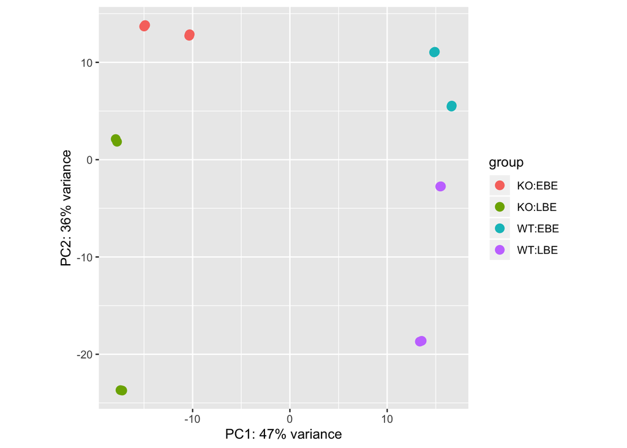

```r
# make PCA plot of vsd
plotPCA(vsd, intgroup = c("cell_type","cell_stage"))
```

```r
# calculate sample to sample distance of vsd and storing the results in sampleDists
sampleDists <- dist(t(assay(vsd)))
sampleDists
```

```
##            SRR2923145 SRR2923146 SRR2923143 SRR2923144 SRR2923141 SRR2923142
## SRR2923146   28.52463
## SRR2923143  103.27985  103.44665
## SRR2923144  103.17656  103.36172   22.03203
## SRR2923141   85.79593   85.95469   91.10236   91.17389
## SRR2923142   85.71024   85.81140   90.95237   90.96971   22.82932
## SRR2923139  108.74936  108.83091   64.48493   64.53047   83.88293   83.61989
## SRR2923140  108.89480  108.88735   64.46552   64.51460   83.81752   83.54666
## SRR2923137   98.03053   98.14089   67.48452   67.50022   90.99739   90.96791
## SRR2923138   98.04303   98.12447   67.64227   67.56794   90.81728   90.78633
## SRR2923135  111.30689  111.46078   64.03339   64.04370  101.73229  101.64233
## SRR2923136  111.13392  111.33323   63.78305   63.78071  101.66221  101.54181
## SRR2923133  102.16731  102.20149   83.52655   83.56237   81.71561   81.41172
## SRR2923134  102.27039  102.32931   83.60869   83.59750   81.84231   81.51455
## SRR2923131  106.17994  106.37247   72.82328   72.80052   81.72788   81.60124
## SRR2923132  106.13451  106.28325   72.77647   72.70912   81.71442   81.54786
##            SRR2923139 SRR2923140 SRR2923137 SRR2923138 SRR2923135 SRR2923136
## SRR2923146
## SRR2923143
## SRR2923144
## SRR2923141
## SRR2923142
## SRR2923139
## SRR2923140   21.81912
## SRR2923137   81.41883   81.47109
## SRR2923138   81.50203   81.50703   23.36504
## SRR2923135   78.03654   78.21507   71.25783   71.50967
## SRR2923136   78.05608   78.28243   71.13664   71.32307   20.92660
## SRR2923133   78.07673   77.96498   82.73598   82.76671   92.11757   91.87563
## SRR2923134   78.06686   78.00707   82.93044   82.90522   92.26543   91.90143
## SRR2923131   65.05913   64.96988   78.27061   78.39012   79.86885   79.77390
## SRR2923132   65.07461   65.00941   78.30302   78.40380   80.02437   79.83706
##            SRR2923133 SRR2923134 SRR2923131
## SRR2923146
## SRR2923143
## SRR2923144
## SRR2923141
## SRR2923142
## SRR2923139
## SRR2923140
## SRR2923137
## SRR2923138
## SRR2923135
## SRR2923136
## SRR2923133
## SRR2923134   26.85804
## SRR2923131   69.37704   69.61258
## SRR2923132   69.53805   69.67831   21.98137
```

Here sampleDists is converted to a matrix and saved as sampleDistMatrix. Row names are assigned as the “cell type - cell stage”. The column names are removed and colors is specified as green from the package RColorBrewer.

```r
# create sample matrix
sampleDistMatrix <- as.matrix( sampleDists )
rownames(sampleDistMatrix) <- paste( vsd$cell_type, vsd$cell_stage, sep = " - " )
colnames(sampleDistMatrix) <- NULL
colors <- colorRampPalette( rev(brewer.pal(9, "Greens")) )(255)
```

### Heatmap Plot

Heatmap plotting `sampleDists` on both axes. The darker the green squares are, the more similar the samples are from each other “shorter distances between the 2 samples”. The clustering on top and on the left of the graph along with the color intensity show that each 2 samples in a row are technical replicates. Also, the first two samples appear to be more different than the other samples. Overall, the heatmap shows three levels of clustering, from strongest to weakest: 1)technical replicates samples, 2) samples of same cell type, 3)samples of same cell stage.

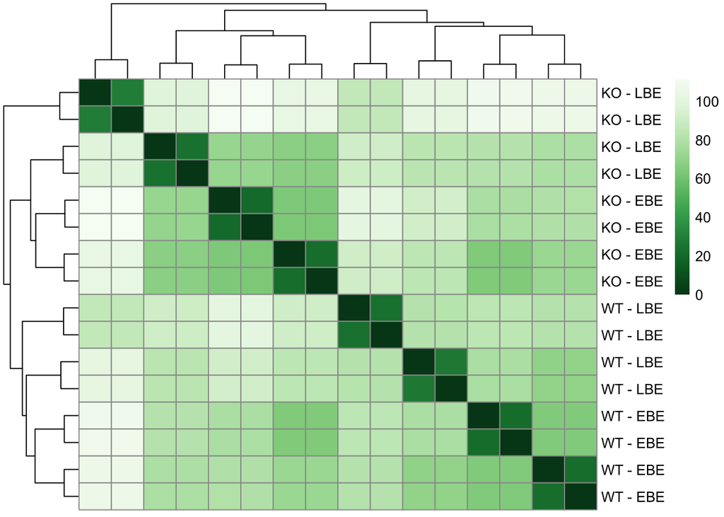

```r
# make a heatmap graph of the sample matrix showing sample distances on both axes
pheatmap(sampleDistMatrix,
         clustering_distance_rows = sampleDists,
         clustering_distance_cols = sampleDists,
         col = colors)
```

Calculate poisson distance for the samples and saving results in poisd. Then creating a matrix of the distances results and saving it as samplePoisDistMatrix. Then, the row names are assigned as the “cell type - cell stage”. The column names are removed and colors is specified as green from the package RColorBrewer.

```r
poisd <- PoissonDistance(t(counts(dds)))
samplePoisDistMatrix <- as.matrix( poisd$dd )
rownames(samplePoisDistMatrix) <- paste( dds$cell_type, dds$cell_stage, sep=" - " )
colnames(samplePoisDistMatrix) <- NULL
```

Heatmap plotting `poisd$dd` on both axes. The darker the green squares are, the more similar the samples are from each other “shorter distances between the 2 samples”. The clustering on top and on the left of the graph along with the color intensity show that each 2 samples in a row are technical replicates. Also, the third and fourth samples appear to be more different than the other samples. Overall, the heatmap shows three levels of clustering, from strongest to weakest: 1)technical replicates samples, 2) samples of same cell stage, 3)samples of same cell type

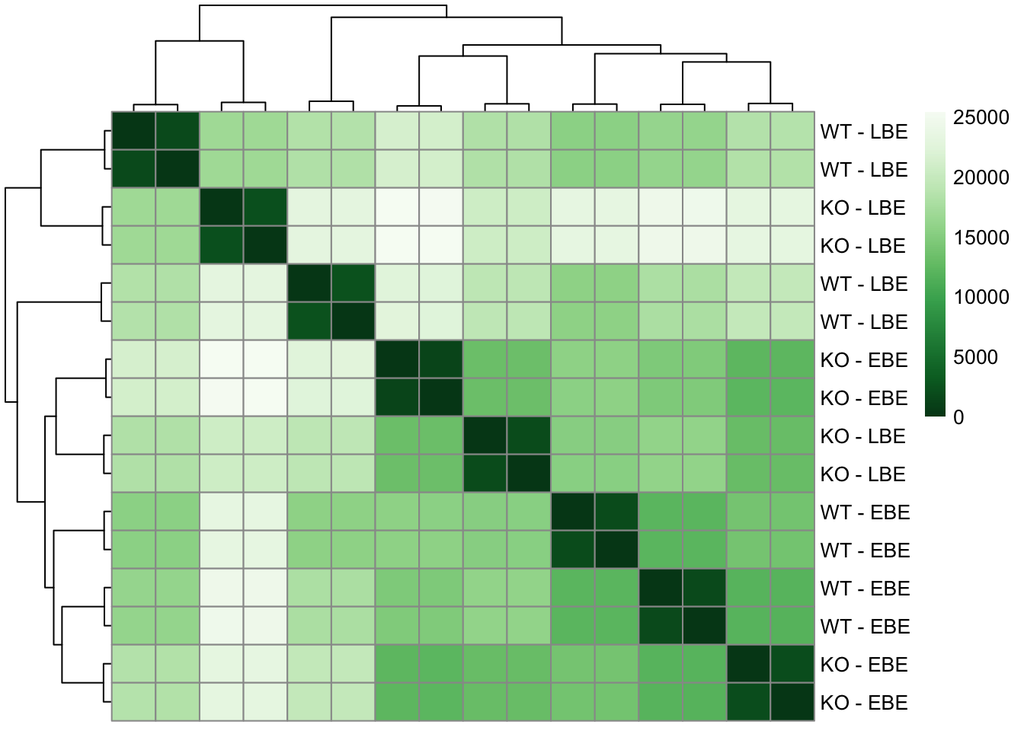

```r
# create heatmap plot of poisd showing sample distances on both axes
pheatmap(samplePoisDistMatrix,
         clustering_distance_rows = poisd$dd,
         clustering_distance_cols = poisd$dd,
         col = colors)
```

## Differential Expression Analysis

Using DESeq function to do the differential expression on dds. DESeq perform estimation of size factors and estimation of dispersion on the raw data. It also perform a negative binomial generalized linear model fitting for the coefficients and Wald statistics.

```r
dds <- DESeq(dds)
```

```
## -- replacing outliers and refitting for 45 genes
## -- DESeq argument 'minReplicatesForReplace' = 7
## -- original counts are preserved in counts(dds)
```

```r
# view the information about the genes
rowRanges(dds)
```

```
## GRanges object with 58037 ranges and 26 metadata columns:
##                      seqnames              ranges strand |            gene_id
##                         <Rle>           <IRanges>  <Rle> |        <character>
##   ENSG00000000003.14     chrX 100627109-100639991      - | ENSG00000000003.14
##    ENSG00000000005.5     chrX 100584802-100599885      + |  ENSG00000000005.5
##   ENSG00000000419.12    chr20   50934867-50958555      - | ENSG00000000419.12
##   ENSG00000000457.13     chr1 169849631-169894267      - | ENSG00000000457.13
##   ENSG00000000460.16     chr1 169662007-169854080      + | ENSG00000000460.16
##                  ...      ...                 ...    ... .                ...
##    ENSG00000283695.1    chr19   52865369-52865429      - |  ENSG00000283695.1
##    ENSG00000283696.1     chr1 161399409-161422424      + |  ENSG00000283696.1
##    ENSG00000283697.1     chrX 149548210-149549852      - |  ENSG00000283697.1
##    ENSG00000283698.1     chr2 112439312-112469687      - |  ENSG00000283698.1
##    ENSG00000283699.1    chr10   12653138-12653197      - |  ENSG00000283699.1
##                      bp_length          symbol          baseMean
##                      <integer> <CharacterList>         <numeric>
##   ENSG00000000003.14      4535          TSPAN6   140.69616460987
##    ENSG00000000005.5      1610            TNMD 0.299159695766911
##   ENSG00000000419.12      1207            DPM1  517.073804380768
##   ENSG00000000457.13      6883           SCYL3  212.098097096209
##   ENSG00000000460.16      5967        C1orf112   320.71698357613
##                  ...       ...             ...               ...
##    ENSG00000283695.1        61            <NA>                 0
##    ENSG00000283696.1       997            <NA>  2.28484698458302
##    ENSG00000283697.1      1184           HSFX3  17.5248581855974
##    ENSG00000283698.1       940            <NA> 0.115438019997961
##    ENSG00000283699.1        60         MIR4481 0.234155680754897
##                                 baseVar   allZero         dispGeneEst
##                               <numeric> <logical>           <numeric>
##   ENSG00000000003.14   5450.85311172734     FALSE   0.238755797557694
##    ENSG00000000005.5  0.451938990521615     FALSE               1e-08
##   ENSG00000000419.12   16455.0075710236     FALSE  0.0596291851051352
##   ENSG00000000457.13   595.799597939225     FALSE 0.00650475131479157
##   ENSG00000000460.16   4139.19336112007     FALSE  0.0300151848375332
##                  ...                ...       ...                 ...
##    ENSG00000283695.1                  0      TRUE                <NA>
##    ENSG00000283696.1   13.6662592947016     FALSE    3.52444592700356
##    ENSG00000283697.1   85.2268648099513     FALSE   0.263697445975445
##    ENSG00000283698.1 0.0995003378731409     FALSE               1e-08
##    ENSG00000283699.1  0.461013988127004     FALSE                  16
```

[output cut: 78 more lines]

```
##                              deviance  maxCooks   replace
##                             <numeric> <logical> <logical>
##   ENSG00000000003.14 175.233907099243      <NA>     FALSE
##    ENSG00000000005.5 23.8858566042379      <NA>     FALSE
##   ENSG00000000419.12 198.371975896254      <NA>     FALSE
##   ENSG00000000457.13  146.76321835301      <NA>     FALSE
##   ENSG00000000460.16 174.245564120313      <NA>     FALSE
##                  ...              ...       ...       ...
##    ENSG00000283695.1             <NA>      <NA>      <NA>
##    ENSG00000283696.1 60.4109733453383      <NA>     FALSE
##    ENSG00000283697.1 115.066656960409      <NA>     FALSE
##    ENSG00000283698.1 14.9531247056629      <NA>     FALSE
##    ENSG00000283699.1 16.7956661146775      <NA>     FALSE
##   -------
##   seqinfo: 25 sequences (1 circular) from an unspecified genome; no seqlengths
```

```r
# view the assay names
assayNames(dds)
```

```
## [1] "counts"        "mu"            "H"             "cooks"
## [5] "replaceCounts" "replaceCooks"
```

```r
# view the information about counts per gene for each sample "the count table"
colData(dds)
```

```
## DataFrame with 16 rows and 25 columns
##                project      sample  experiment         run
##            <character> <character> <character> <character>
## SRR2923145   SRP066151  SRS1161495  SRX1430708  SRR2923145
## SRR2923146   SRP066151  SRS1161495  SRX1430708  SRR2923146
## SRR2923143   SRP066151  SRS1161496  SRX1430707  SRR2923143
## SRR2923144   SRP066151  SRS1161496  SRX1430707  SRR2923144
## SRR2923141   SRP066151  SRS1161497  SRX1430706  SRR2923141
## ...                ...         ...         ...         ...
## SRR2923136   SRP066151  SRS1161500  SRX1430703  SRR2923136
## SRR2923133   SRP066151  SRS1161501  SRX1430702  SRR2923133
## SRR2923134   SRP066151  SRS1161501  SRX1430702  SRR2923134
## SRR2923131   SRP066151  SRS1161502  SRX1430701  SRR2923131
## SRR2923132   SRP066151  SRS1161502  SRX1430701  SRR2923132
##            read_count_as_reported_by_sra reads_downloaded
##                                <integer>        <integer>
## SRR2923145                      53991816         53991816
## SRR2923146                      53083064         53083064
## SRR2923143                      59346502         59346502
## SRR2923144                      59932408         59932408
## SRR2923141                      64798976         64798976
## ...                                  ...              ...
## SRR2923136                      58647000         58647000
## SRR2923133                      64321850         64321850
## SRR2923134                      65097422         65097422
## SRR2923131                      63740456         63740456
## SRR2923132                      64552440         64552440
##            proportion_of_reads_reported_by_sra_downloaded paired_end
##                                                 <numeric>  <logical>
## SRR2923145                                              1       TRUE
## SRR2923146                                              1       TRUE
## SRR2923143                                              1       TRUE
## SRR2923144                                              1       TRUE
## SRR2923141                                              1       TRUE
## ...                                                   ...        ...
## SRR2923136                                              1       TRUE
## SRR2923133                                              1       TRUE
## SRR2923134                                              1       TRUE
## SRR2923131                                              1       TRUE
## SRR2923132                                              1       TRUE
```

[output cut: 63 more lines]

```
## SRR2923131  differentiation stage: Early basophilic erythroblasts,culture condition: SFEM doxycycline+ (Day0),mouse strain: NA
## SRR2923132  differentiation stage: Early basophilic erythroblasts,culture condition: SFEM doxycycline+ (Day0),mouse strain: NA
##            cell_type cell_stage        sizeFactor replaceable
##             <factor>   <factor>         <numeric>   <logical>
## SRR2923145        KO        LBE  0.80144601790212        TRUE
## SRR2923146        KO        LBE 0.799359524425457        TRUE
## SRR2923143        KO        EBE  1.18800600392369        TRUE
## SRR2923144        KO        EBE  1.18705614980096        TRUE
## SRR2923141        WT        LBE 0.969113952324156        TRUE
## ...              ...        ...               ...         ...
## SRR2923136        KO        EBE 0.984434120292914        TRUE
## SRR2923133        WT        LBE  1.01609614860798        TRUE
## SRR2923134        WT        LBE  1.01873219664174        TRUE
## SRR2923131        WT        EBE  1.08903890214189        TRUE
## SRR2923132        WT        EBE  1.08895379345734        TRUE
```

## Build results tables

```r
# store results of DESeq in res
res <- results(dds)
# view results
head(res)
```

```
## log2 fold change (MLE): cell type WT vs KO
## Wald test p-value: cell type WT vs KO
## DataFrame with 6 rows and 6 columns
##                             baseMean     log2FoldChange             lfcSE
##                            <numeric>          <numeric>         <numeric>
## ENSG00000000003.14   140.69616460987  -1.14245662846797 0.339180811935318
## ENSG00000000005.5  0.299159695766911   1.69142407936114  3.04371769777611
## ENSG00000000419.12  517.073804380768 0.0392804650940042 0.179662103581557
## ENSG00000000457.13  212.098097096209  0.151147897814213 0.103273850851569
## ENSG00000000460.16   320.71698357613   0.32784421813511 0.143978031846495
## ENSG00000000938.12  1.21096252972251  -3.33396436940428  1.46369852124451
##                                 stat               pvalue               padj
##                            <numeric>            <numeric>          <numeric>
## ENSG00000000003.14 -3.36828201439013 0.000756381834801874 0.0134678104858511
## ENSG00000000005.5  0.555709907195721     0.57840918276072                 NA
## ENSG00000000419.12 0.218635228637257    0.826934208153543   0.94254210771776
## ENSG00000000457.13  1.46356407326625    0.143313094857562  0.430037308855352
## ENSG00000000460.16  2.27704333731029   0.0227836378181144  0.150049010571761
## ENSG00000000938.12  -2.2777671228154   0.0227404561294184   0.14993837658226
```

```r
# view res columns metadata
mcols(res, use.names = TRUE)
```

```
## DataFrame with 6 rows and 2 columns
##                        type                                description
##                 <character>                                <character>
## baseMean       intermediate  mean of normalized counts for all samples
## log2FoldChange      results log2 fold change (MLE): cell type WT vs KO
## lfcSE               results         standard error: cell type WT vs KO
## stat                results         Wald statistic: cell type WT vs KO
## pvalue              results      Wald test p-value: cell type WT vs KO
## padj                results                       BH adjusted p-values
```

```r
# viewing the summary of the results table
summary(res)
```

```
##
## out of 47399 with nonzero total read count
## adjusted p-value < 0.1
## LFC > 0 (up)       : 2088, 4.4%
## LFC < 0 (down)     : 1798, 3.8%
## outliers [1]       : 0, 0%
## low counts [2]     : 15438, 33%
## (mean count < 1)
## [1] see 'cooksCutoff' argument of ?results
## [2] see 'independentFiltering' argument of ?results
```

```r
# creating another results table with lower alpha value at 0.05
res.05 <- results(dds, alpha = 0.05)
table(res.05$padj < 0.05)
```

```
##
## FALSE  TRUE
## 28232  2821
```

```r
# creating another results table with higher lfcThreshold (value at 1)
resLFC1 <- results(dds, lfcThreshold=1)
table(resLFC1$padj < 0.1)
```

```
##
## FALSE  TRUE
## 27996   333
```

## Multiple testing

The goal here is to limit false positive genes to be identified as significant (differentially expressed)

```r
# Summing the number of genes with p-value less than 0.05. The sum is 6662 genes.

sum(res$pvalue < 0.05, na.rm=TRUE)
```

```
## [1] 6662
```

```r
#Summing the number of genes with any reported p-value "not NA". 47399 genes were included.

sum(!is.na(res$pvalue))
```

```
## [1] 47399
```

```r
# Summing the number of genes with adjusted p-value less than 0.1 "10% FDR". The sum is 3886 genes.

sum(res$padj < 0.1, na.rm=TRUE)
```

```
## [1] 3886
```

Selecting the significant genes with adjusted p-value less than 0.1 and storing them in resSig. Looking at the top 6 down regulated genes by ordering the genes from the lowest log2FoldChange value.

```r
# results saved as resSig
resSig <- subset(res, padj < 0.1)
head(resSig[ order(resSig$log2FoldChange), ])
```

```
## log2 fold change (MLE): cell type WT vs KO
## Wald test p-value: cell type WT vs KO
## DataFrame with 6 rows and 6 columns
##                            baseMean    log2FoldChange             lfcSE
##                           <numeric>         <numeric>         <numeric>
## ENSG00000130600.16 394.700750658056 -11.7616770420298 0.979193782888153
## ENSG00000224695.1  40.1037084915945 -8.82297500575032  1.55001095162623
## ENSG00000260629.1   50.049830587879 -8.41621291283528  1.03607884357895
## ENSG00000124440.15 1343.60189914438 -8.08847182538646 0.542406072583179
## ENSG00000103187.7  772.980856474193 -7.72668554916084 0.654579600080413
## ENSG00000163629.12 399.087064837832 -7.65615463083135 0.758548729397401
##                                 stat               pvalue                 padj
##                            <numeric>            <numeric>            <numeric>
## ENSG00000130600.16 -12.0115928507415 3.08838466818181e-33 4.70037439903613e-30
## ENSG00000224695.1  -5.69220172057074  1.2541156232703e-08 1.00710526219453e-06
## ENSG00000260629.1   -8.1231394357624 4.54276907126319e-16  1.2963521632736e-13
## ENSG00000124440.15 -14.9122073557649 2.74524839880321e-50 8.77408840741494e-47
## ENSG00000103187.7  -11.8040426988737 3.72000508670451e-32 4.40352157689492e-29
## ENSG00000163629.12 -10.0931612355524 5.92306860898241e-24 3.64052299637859e-21
```

Here looking at the top 6 up-regulated genes by ordering the genes from the highest log2FoldChange value.

```r
head(resSig[ order(resSig$log2FoldChange, decreasing = TRUE), ])
```

```
## log2 fold change (MLE): cell type WT vs KO
## Wald test p-value: cell type WT vs KO
## DataFrame with 6 rows and 6 columns
##                            baseMean   log2FoldChange             lfcSE
##                           <numeric>        <numeric>         <numeric>
## ENSG00000180353.10 24.4108077900429 8.04182051408828 0.785926678598961
## ENSG00000172005.10 16.9224979894807 7.14763128830538 0.963973889252971
## ENSG00000100078.3  9.97812744668523 6.75073249335201  1.25820919607917
## ENSG00000114405.10 13.7139940476211 6.47805419567476 0.895448044195545
## ENSG00000166707.10  8.1979392371866 6.46799675320489    1.306519360236
## ENSG00000178202.12 7.66541711432825 6.37259524729764 0.931299201337505
##                                stat               pvalue                 padj
##                           <numeric>            <numeric>            <numeric>
## ENSG00000180353.10 10.2322783194281 1.42135502511414e-24 9.08558559153458e-22
## ENSG00000172005.10  7.4147561132018 1.21848824616143e-13 2.38920876291814e-11
## ENSG00000100078.3  5.36534982766667 8.07924760353323e-08 5.58919551204601e-06
## ENSG00000114405.10 7.23442776793883 4.67496074912573e-13 8.34728606160935e-11
## ENSG00000166707.10 4.95055561368534 7.40019059729918e-07 4.02925880204905e-05
## ENSG00000178202.12 6.84269377461669   7.771767120157e-12 1.17722013709639e-09
```

## Plotting results

Here plotting the results for the most significant gene and grouping the results by cell_type and cell_stage. The plot shows separation based on cell_type, where the normalized count for WT is above 500 and below 200 for KO.

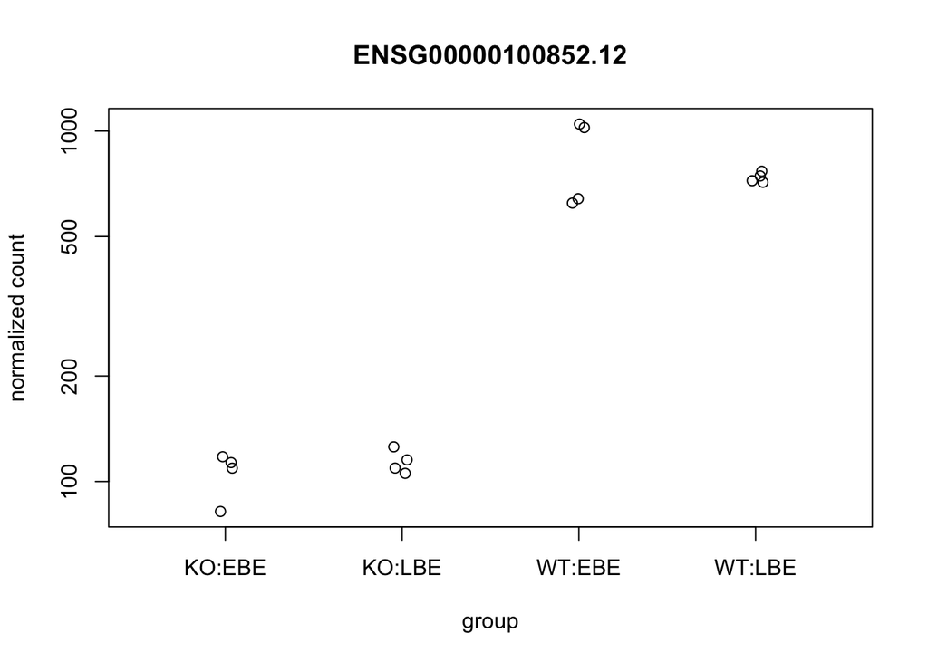

```r
# gene with the lowest padj value
topGene <- rownames(res)[which.min(res$padj)]
plotCounts(dds, gene = topGene, intgroup=c("cell_type","cell_stage"))
```

Here plotting the results for the most significant gene and grouping the results by cell_type only. As in previous plot, this plot shows separation based on cell_type.

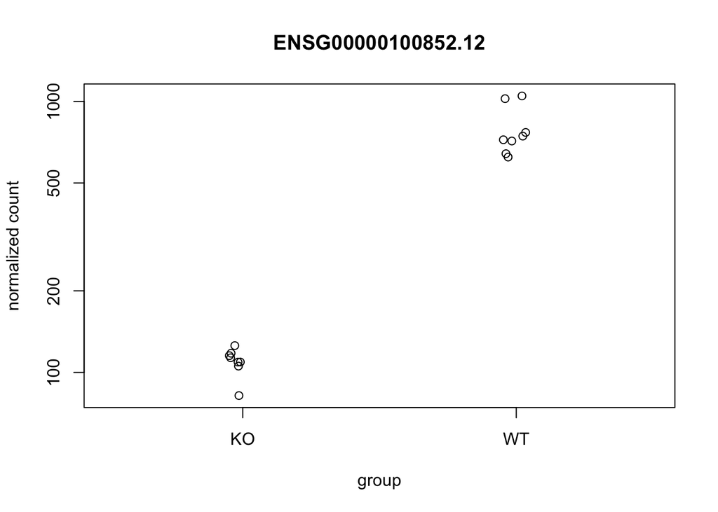

```r
plotCounts(dds, gene = topGene, intgroup="cell_type")
```

Creating an MA plot, which show the log2 fold change value for each gene. Also, identifying topGene (gene with the lowest padj value) on the plot.

```r
# MA plot with most significant gene
res.MA <- lfcShrink(dds, coef="cell_type_WT_vs_KO", type="apeglm")
```

```
## using 'apeglm' for LFC shrinkage. If used in published research, please cite:
##     Zhu, A., Ibrahim, J.G., Love, M.I. (2018) Heavy-tailed prior distributions for
##     sequence count data: removing the noise and preserving large differences.
##     Bioinformatics. https://doi.org/10.1093/bioinformatics/bty895
```

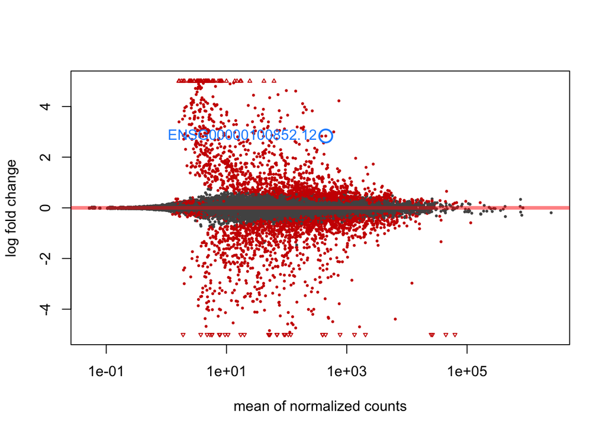

```r
plotMA(res.MA, ylim = c(-5, 5))
# plot with most significant gene
topGene <- rownames(res.MA)[which.min(res.MA$padj)]
with(res.MA[topGene, ], {
  points(baseMean, log2FoldChange, col="dodgerblue", cex=2, lwd=2)
  text(baseMean, log2FoldChange, topGene, pos=2, col="dodgerblue")
})
```

### Gene Clustering

Plotting the top 20 most variable genes are selected from vsd. This is achieved by using rowVars function form genefilter package, which calculates the variance for each row “gene” across samples. Then the genes are ordered from the most to least variable. The top 20 row numbers are stored in topVarGenes.

Then creating the heatmap with the results. The rows represent the genes while the columns represent the samples. The two bars at the top of the heatmap represent cell type and cell stage for each sample. All samples appear to cluster by cell type. With the exception to the top three genes in the plot, all the other genes are up-regulated for cell type KO in right side and down-regulated for cell type WT in the left side. Gene ENSG00000069011.15 has the opposite expression. With in each cell type, samples with the same cell stage cluster together.

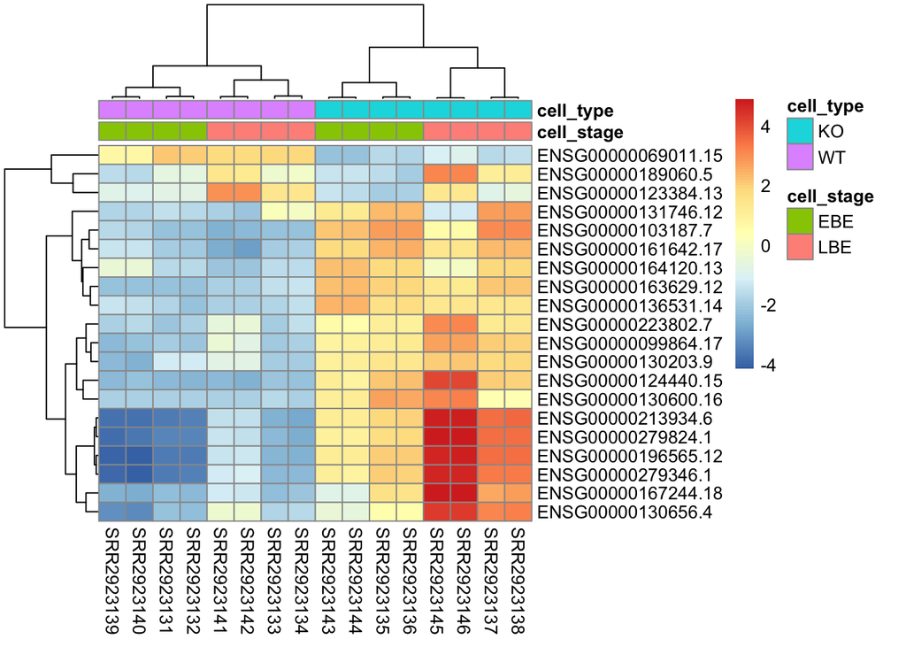

```r
# gene clustering heatmap of a subset of the most highly variable genes

topVarGenes <- head(order(rowVars(assay(vsd)), decreasing = TRUE), 20)

mat  <- assay(vsd)[ topVarGenes, ]
mat  <- mat - rowMeans(mat)
anno <- as.data.frame(colData(vsd)[, c("cell_stage","cell_type")])
pheatmap(mat, annotation_col = anno)
```

## Annotating and exporting results

Viewing the columns of org.Hs.eg.db package, which is specific for humans. Information from these columns can be retrieved and added to the results of the differential expression `res`. Adding gene SYMBOLs and ENTREZIDs.

```r
# adding annotaion to res table
columns(org.Hs.eg.db)
```

```
##  [1] "ACCNUM"       "ALIAS"        "ENSEMBL"      "ENSEMBLPROT"  "ENSEMBLTRANS"
##  [6] "ENTREZID"     "ENZYME"       "EVIDENCE"     "EVIDENCEALL"  "GENENAME"
## [11] "GO"           "GOALL"        "IPI"          "MAP"          "OMIM"
## [16] "ONTOLOGY"     "ONTOLOGYALL"  "PATH"         "PFAM"         "PMID"
## [21] "PROSITE"      "REFSEQ"       "SYMBOL"       "UCSCKG"       "UNIGENE"
## [26] "UNIPROT"
```

```r
ens.str <- substr(rownames(res), 1, 15)
res$symbol <- mapIds(org.Hs.eg.db,
                     keys=ens.str,
                     column="SYMBOL",
                     keytype="ENSEMBL",
                     multiVals="first")
res$entrez <- mapIds(org.Hs.eg.db,
                     keys=ens.str,
                     column="ENTREZID",
                     keytype="ENSEMBL",
                     multiVals="first")
```

Adding gene SYMBOLs and ENTREZIDs to resSig table. resSig is a subset of res with significant genes that have adjusted p-value less than 0.1

```r
# adding annotaion to resSig table

ens.str2 <- substr(rownames(resSig), 1, 15)
resSig$symbol <- mapIds(org.Hs.eg.db,
                     keys=ens.str2,
                     column="SYMBOL",
                     keytype="ENSEMBL",
                     multiVals="first")
resSig$entrez <- mapIds(org.Hs.eg.db,
                     keys=ens.str2,
                     column="ENTREZID",
                     keytype="ENSEMBL",
                     multiVals="first")
```

Saving gene SYMBOLs and ENTREZIDs for all the genes in genesSymbols and genesEntrez

```r
# Saving annotations for genes symbols and IDs
# all genes names

ens.str.dds <- substr(rownames(dds), 1, 15)
genesSymbols <- mapIds(org.Hs.eg.db,
                      keys=ens.str.dds,
                      column="SYMBOL",
                      keytype="ENSEMBL",
                      multiVals="first")
# all genes IDs
genesEntrez <- mapIds(org.Hs.eg.db,
                     keys=ens.str.dds,
                     column="ENTREZID",
                     keytype="ENSEMBL",
                     multiVals="first")
```

## Exporting results

Ordering resSig table by padj value

```r
# reorder table by padj value
resSigOrdered <- resSig[order(resSig$padj), ]
head(resSigOrdered)
```

```
## log2 fold change (MLE): cell type WT vs KO
## Wald test p-value: cell type WT vs KO
## DataFrame with 6 rows and 8 columns
##                            baseMean    log2FoldChange             lfcSE
##                           <numeric>         <numeric>         <numeric>
## ENSG00000100852.12 447.105054220154  2.84902648198082 0.139585466905406
## ENSG00000104833.11  230.62895663951 -4.03409832253798 0.222056269904634
## ENSG00000136531.14  443.23315961252 -5.74048237749063 0.325707413531836
## ENSG00000105426.15 121.150990218246 -4.58379131098472 0.283837601456459
## ENSG00000268191.1  106.420886492151  -5.6180647865515 0.357907205264758
## ENSG00000283229.1  104.090178415623 -4.62307626119577 0.296860230516532
##                                 stat               pvalue                 padj
##                            <numeric>            <numeric>            <numeric>
## ENSG00000100852.12   20.410624007953 1.34555863931578e-92 4.30053996711715e-88
## ENSG00000104833.11 -18.1670093092643 9.41945579151782e-74  1.5052761327635e-69
## ENSG00000136531.14 -17.6246598603428 1.59323994887664e-69 1.69738473353488e-65
## ENSG00000105426.15 -16.1493448629211 1.14774201784212e-58 9.17074565806298e-55
## ENSG00000268191.1  -15.6969871070229 1.58597556011046e-55 1.01378729753381e-51
## ENSG00000283229.1  -15.5732421724247 1.10653331038695e-54 5.89431852221287e-51
##                         symbol      entrez
##                    <character> <character>
## ENSG00000100852.12     ARHGAP5         394
## ENSG00000104833.11      TUBB4A       10382
## ENSG00000136531.14       SCN2A        6326
## ENSG00000105426.15       PTPRS        5802
## ENSG00000268191.1           NA          NA
## ENSG00000283229.1           NA          NA
```

One way to save the results is by subsetting the desire number of rows then saving the results into a new variable. Here the top 100 genes with lowest p-values are saved in resOrderedDF “a data frame”. Then from the data frame a CSV file is created “results.csv”.

```r
resSigOrderedDF <- as.data.frame(resSigOrdered)[1:100, ]
write.csv(resSigOrderedDF, file = "results.csv")
```

Another way to export is by creating an HTML file with the results. Here the data frame is put in htmlRep, an HTML document that was created with HTMLReport function. htmlRep then be viewed in a web browser for more interactivity.

```r
library("ReportingTools")
htmlRep <- HTMLReport(shortName="report", title="My report",
                      reportDirectory="./report")
publish(resSigOrderedDF, htmlRep)
url <- finish(htmlRep)
browseURL(url)
```

## surrogate variable analysis

The goal of surrogate variable analysis is to detect unknown and unwanted variation that may affect gene expression results.

The following line retrieve the read counts from dds and normalizing them argument normalized = TRUE. The results is stored in dat. Then, evaluating if the row mean for each gene is greater than 1. The results is stored in idx. After that subsetting the genes “rows” with row mean greater than 1. Results is stored back in dat. The creating two models, one indicating cell type status and intercept for each sample and another indicating only the intercepts. Then using svaseq to indicate 2 surrogate variables per sample.

```r
dat  <- counts(dds, normalized = TRUE)
idx  <- rowMeans(dat) > 1
dat  <- dat[idx, ]
mod  <- model.matrix(~ cell_type, colData(dds))
mod0 <- model.matrix(~   1, colData(dds))
svseq <- svaseq(dat, mod, mod0, n.sv = 2)
```

```
## Number of significant surrogate variables is:  2
## Iteration (out of 5 ):1  2  3  4  5
```

```r
svseq$sv
```

```
##              [,1]         [,2]
##  [1,]  0.48048842  0.243686001
##  [2,]  0.48284493  0.240949432
##  [3,] -0.12817518 -0.003591489
##  [4,] -0.12809653 -0.003067663
##  [5,]  0.06237840  0.375044725
##  [6,]  0.06187757  0.369743970
##  [7,] -0.12798138  0.087862408
##  [8,] -0.12614064  0.084708785
##  [9,] -0.08947636 -0.210630869
## [10,] -0.08501511 -0.215549207
## [11,] -0.37212176  0.035915870
## [12,] -0.36679220  0.034679728
## [13,]  0.27438635 -0.497770068
## [14,]  0.27664997 -0.498214419
## [15,] -0.10692617 -0.023257593
## [16,] -0.10790030 -0.020509611
```

Plotting the 2 surrogate to show that cell_stage is the unknown factor that is affecting expression in samples.

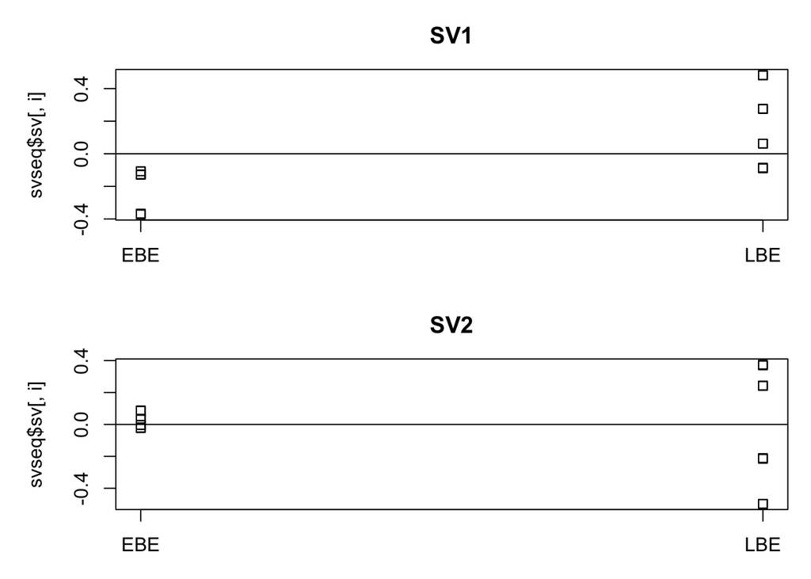

```r
# plotting sva
par(mfrow = c(2, 1), mar = c(3,5,3,1))
for (i in 1:2) {
  stripchart(svseq$sv[, i] ~ dds$cell_stage, vertical = TRUE, main = paste0("SV", i))
  abline(h = 0)
}
```

## pathway enrichment analysis

Finding the pathways that are more representative in the genes in resSig than the rest of the genes.

Here using reactome package to find the pathways. Using the ENTREZIDs of the genes as input. Also indicating pvalueCutoff = 0.05 and Benjamini and Hochberg false discovery test.

```r
reactome_enrich <- enrichPathway(gene = resSig$entrez ,
                                 universe = res$entrez,

                                 organism = "human",
                                 pvalueCutoff = 0.05,
                                 pAdjustMethod = "BH",
                                 qvalueCutoff = 0.9,

                                 readable = TRUE)
```

The results show only one pathway. Rho GTPase cycle pathway.

```r
# Viewing the results
head(as.data.frame(reactome_enrich))
```

```
##                        ID      Description GeneRatio   BgRatio       pvalue
## R-HSA-194840 R-HSA-194840 Rho GTPase cycle   37/1468 137/10574 3.538087e-05
##                p.adjust     qvalue
## R-HSA-194840 0.04748112 0.04573443
##                                                                                                                                                                                                                                                                      geneID
## R-HSA-194840 RALBP1/ARHGAP31/NGEF/ARHGAP15/ARHGEF1/PLEKHG2/SYDE2/MYO9B/AR…
##              Count
## R-HSA-194840    37
```

Plotting the pathway. On the x-axis is the number of genes known to have this pathway. On the y-axis is the name of the pathway.

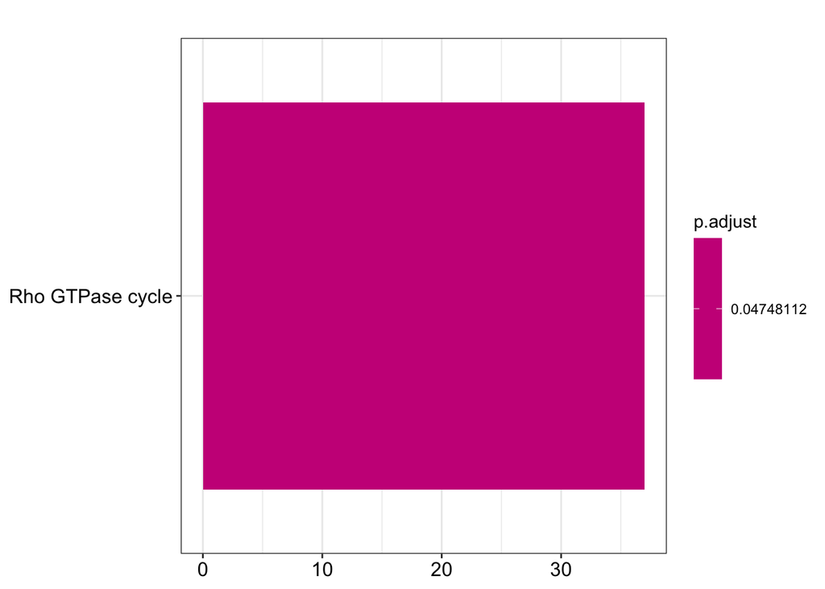

```r
barplot(reactome_enrich)
```

```r
enrich_go <- enrichGO(
     gene = resSig$entrez,
     OrgDb = org.Hs.eg.db, keyType = "ENTREZID", ont = "MF",
     pAdjustMethod = "BH", pvalueCutoff = 0.05, qvalueCutoff = 0.2,
     universe = res$entrez)

head(enrich_go)
```

```
##                    ID                                 Description GeneRatio
## GO:0050839 GO:0050839              cell adhesion molecule binding  100/2303
## GO:0045296 GO:0045296                            cadherin binding   67/2303
## GO:0019787 GO:0019787 ubiquitin-like protein transferase activity   72/2303
## GO:0004842 GO:0004842      ubiquitin-protein transferase activity   67/2303
## GO:0017016 GO:0017016                          Ras GTPase binding   69/2303
## GO:0051020 GO:0051020                              GTPase binding   86/2303
##              BgRatio       pvalue     p.adjust       qvalue
## GO:0050839 444/16568 4.297817e-07 0.0004108713 0.0003994707
## GO:0045296 297/16568 3.148505e-05 0.0134482695 0.0130751178
## GO:0019787 328/16568 4.220168e-05 0.0134482695 0.0130751178
## GO:0004842 304/16568 6.742677e-05 0.0151996601 0.0147779122
## GO:0017016 317/16568 7.949613e-05 0.0151996601 0.0147779122
## GO:0051020 423/16568 1.473537e-04 0.0172177095 0.0167399664
##                                                                                                                                                                                                                                                                                                          …
## GO:0050839 3683/53616/11188/999/822/1829/1496/5214/22859/5817/8301/4854…
## GO:0045296                                                                                                                                                                          999/822/1496/5214/8301/4854/6624/22837/23085/118/2802/51100/…
## GO:0019787                                                                                                                54476/55148/9604/9921/23327/54542/51665/4734/4850/10075/5494…
## GO:0004842                                                                                                                                              54476/55148/9921/23327/54542/51665/4734/4850/10075/54941/513…
## GO:0017016                                                                                                                                  27035/10048/10928/23101/25791/7813/10640/8301/9138/23085/648…
## GO:0051020                                 27035/9265/10048/10928/58528/23101/25791/10565/7813/10235/10…
##            Count
## GO:0050839   100
## GO:0045296    67
## GO:0019787    72
## GO:0004842    67
## GO:0017016    69
## GO:0051020    86
```

Plotting the pathways with dotplot. The size of the dots indicates the number of genes represented in this pathway. The color for the p-adj value. Labels on y-axis with the names of the pathway, and x-axis with the gene ratio.

```
## wrong orderBy parameter; set to default `orderBy = "x"`
```

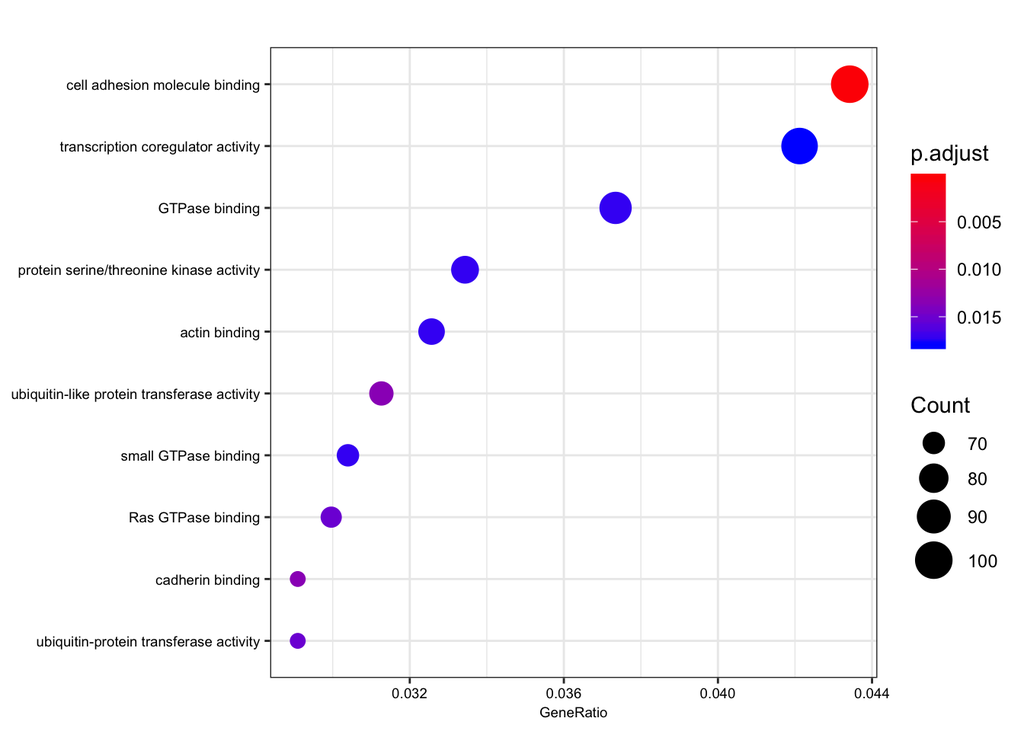

```r
## Visualize enrichment results
dotplot(enrich_go, font.size = 7)
```

Plotting the pathways with barplot. The number of genes on the x-axis and names of pathways on the y-axis. p-adj value indicated by color.

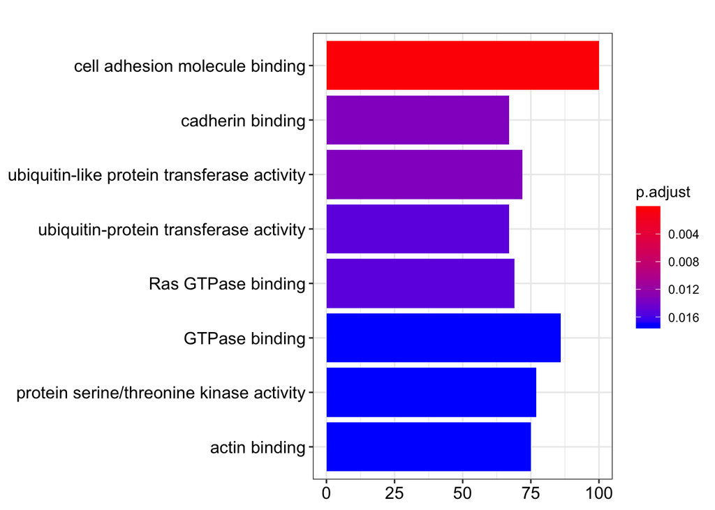

```r
barplot(enrich_go)
```

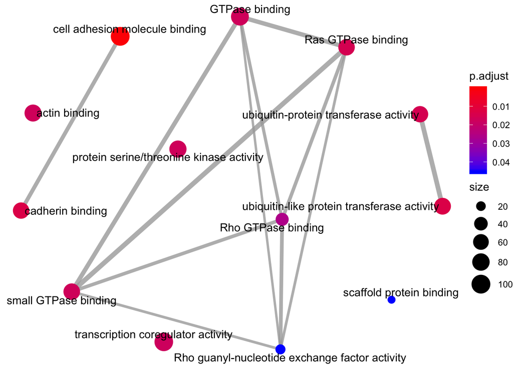

```r
emapplot(enrich_go)
```

```r
enrich_go_symbol <- enrichGO(
     gene = resSig$symbol,
     OrgDb = org.Hs.eg.db, keyType = "SYMBOL", ont = "ALL",
     pAdjustMethod = "BH", pvalueCutoff = 0.05, qvalueCutoff = 0.2,
     universe = res$symbol)

head(enrich_go_symbol)
```

```
##            ONTOLOGY         ID                      Description GeneRatio
## GO:0005912       CC GO:0005912                adherens junction  107/2364
## GO:0030055       CC GO:0030055          cell-substrate junction   87/2364
## GO:0005924       CC GO:0005924 cell-substrate adherens junction   86/2364
## GO:0005925       CC GO:0005925                   focal adhesion   85/2364
## GO:0098984       CC GO:0098984         neuron to neuron synapse   65/2364
## GO:0030120       CC GO:0030120                     vesicle coat   16/2364
##              BgRatio       pvalue     p.adjust       qvalue
## GO:0005912 496/18008 9.454628e-08 6.381874e-05 5.742443e-05
## GO:0030055 404/18008 1.593195e-06 3.953767e-04 3.557620e-04
## GO:0005924 399/18008 1.757230e-06 3.953767e-04 3.557620e-04
## GO:0005925 397/18008 2.668480e-06 4.503060e-04 4.051876e-04
## GO:0098984 315/18008 1.216402e-04 1.642142e-02 1.477608e-02
## GO:0030120  48/18008 2.624296e-04 2.952333e-02 2.656524e-02
##                                                                                                                                                                                                                                                                                                          …
## GO:0005912 CYTH3/MRC2/TSPAN9/EHD3/VIM/ARHGAP31/CDH1/CYBA/TLE2/CTNNA2/PA…
## GO:0030055                                                                                                                          MRC2/TSPAN9/EHD3/VIM/ARHGAP31/CYBA/TLE2/PABPC1/RPL31/PVR/TNS…
## GO:0005924                                                                                                                                MRC2/TSPAN9/EHD3/VIM/ARHGAP31/CYBA/TLE2/PABPC1/RPL31/PVR/TNS…
## GO:0005925                                                                                                                                     MRC2/TSPAN9/EHD3/VIM/ARHGAP31/CYBA/TLE2/PABPC1/RPL31/PVR/TNS…
## GO:0098984                                                                                                                                                                                                               ADAM22/SYT7/PLEKHA5/CTNNA2/KCNAB2/CAMK2A/PALM/CALB1/PTPRS/CA…
## GO:0030120                                                                                                                                                                                                                                                                                               …
##            Count
## GO:0005912   107
## GO:0030055    87
## GO:0005924    86
## GO:0005925    85
## GO:0098984    65
## GO:0030120    16
```

Plotting the pathways with cnetplot where the genes are labeled by their symbols.

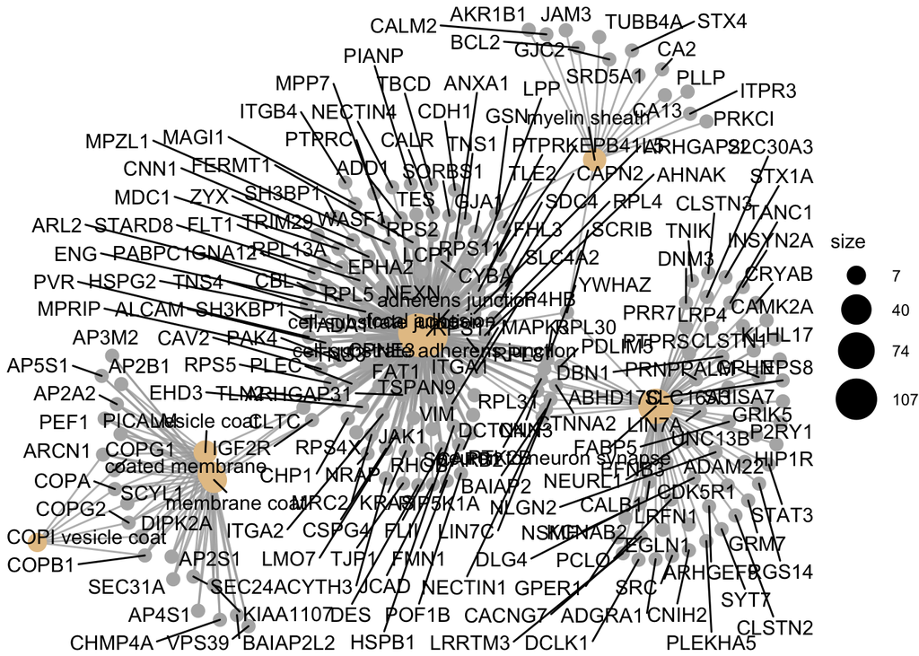

```r
cnetplot(enrich_go_symbol, categorySize="pvalue", showCategory = 10)
```

sessionInfo returns the version of R and a list of packages and their versions in ordered to keep record of what version are/were used.

## Discussion/Results of Top Genes

Top 3 most significant genes based on p-adj value

1. ARHGAP5: makes GTPase Activating Proteins or GAPs, which is one of 3 regulating classes of proteins of Rho GTPase cycle. GAPs are known to deactivate Rho GTPase cycle. This gene was up-regulated.
2. TUBB4A: a gene when mutated is known to be associated with Hypomyelinating leukodystrophy-6, which is neurologic disorder. This gene was down-regulated.
3. SCN2A: a gene when mutated is associated with a number of neurologic disorders autism and seizure disorders. This gene was down-regulated.

```r
head(resSigOrderedDF,3)
```

```
##                    baseMean log2FoldChange     lfcSE      stat       pvalue
## ENSG00000100852.12 447.1051       2.849026 0.1395855  20.41062 1.345559e-92
## ENSG00000104833.11 230.6290      -4.034098 0.2220563 -18.16701 9.419456e-74
## ENSG00000136531.14 443.2332      -5.740482 0.3257074 -17.62466 1.593240e-69
##                            padj  symbol entrez
## ENSG00000100852.12 4.300540e-88 ARHGAP5    394
## ENSG00000104833.11 1.505276e-69  TUBB4A  10382
## ENSG00000136531.14 1.697385e-65   SCN2A   6326
```

Top 3 most significant genes based on absolute log2FoldChange value

1. H19: a gene that produces a lncRNA. It is known to regulate IFG2 gene, which is a growth promoting gene. Mutated of this H19 is associated with unwanted cell growth and diseases like cancers and Beckwith-Wiedemann Syndrome. This gene was down-regulated.
2. HIF3A: a gene that is activated in low oxygen environment. It is known to suppress expressions of growth genes. This gene was down-regulated.
3. HCLS1: a gene that produces an antigen receptor signaling protein. This gene was up-regulated.

```r
head(arrange(resSigOrderedDF,desc(abs(log2FoldChange))),3)
```

```
##     baseMean log2FoldChange     lfcSE      stat       pvalue         padj
## 1  394.70075     -11.761677 0.9791938 -12.01159 3.088385e-33 4.700374e-30
## 2 1343.60190      -8.088472 0.5424061 -14.91221 2.745248e-50 8.774088e-47
## 3   24.41081       8.041821 0.7859267  10.23228 1.421355e-24 9.085586e-22
##   symbol entrez
## 1    H19 283120
## 2  HIF3A  64344
## 3  HCLS1   3059
```

[session information not shown]

## References

Curiel, Julian, G Rodríguez Bey, A Takanohashi, M Bugiani, X Fu, N Wolf, R Schiffmann, et al. “TUBB4A Mutations Result in Specific Neuronal and Oligodendrocytic Defects That Closely Match Clinically Distinct Phenotypes.” Human Molecular Genetics 26, no. 22 (November 16, 2017): 4506–18. https://doi.org/10.1093/hmg/ddx338.

Gabory, A., M.-A. Ripoche, T. Yoshimizu, and L. Dandolo. “The H19 Gene: Regulation and Function of a Non-Coding RNA.” Cytogenetic and Genome Research 113, no. 1–4 (2006): 188–93. https://doi.org/10.1159/000090831.

Hall, Alan. “Rho Family GTPases.” Biochemical Society Transactions 40, no. 6 (November 21, 2012): 1378–82. https://doi.org/10.1042/BST20120103.

Kearney, J.A, N.W Plummer, M.R Smith, J Kapur, T.R Cummins, S.G Waxman, A.L Goldin, and M.H Meisler. “A Gain-of-Function Mutation in the Sodium Channel Gene Scn2a Results in Seizures and Behavioral Abnormalities.” Neuroscience 102, no. 2 (January 15, 2001): 307–17. https://doi.org/10.1016/S0306-4522(00)00479-6.

Love, M, S Anders, V Kim, and W Huber. RNA-Seq Workflow: Gene-Level Exploratory Analysis and Differential Expression, 2019. https://www.bioconductor.org/packages/devel/workflows/vignettes/rnaseqGene/inst/doc/rnaseqGene.html.

Masuda, T., X. Wang, M. Maeda, M. C. Canver, F. Sher, A. P. W. Funnell, C. Fisher, et al. “Transcription Factors LRF and BCL11A Independently Repress Expression of Fetal Hemoglobin.” Science 351, no. 6270 (January 15, 2016): 285–89. https://doi.org/10.1126/science.aad3312.

Semenza, Gregg L. “Hypoxia-Inducible Factors: Mediators of Cancer Progression and Targets for Cancer Therapy.” Trends in Pharmacological Sciences 33, no. 4 (April 2012): 207–14. https://doi.org/10.1016/j.tips.2012.01.005.

Skokowa, Julia, Maxim Klimiankou, Olga Klimenkova, Dan Lan, Kshama Gupta, Kais Hussein, Esteban Carrizosa, et al. “Interactions among HCLS1, HAX1 and LEF-1 Proteins Are Essential for G-CSF–Triggered Granulopoiesis.” Nature Medicine 18, no. 10 (October 1, 2012): 1550–59. https://doi.org/10.1038/nm.2958.